# Modeling Swire Coca Cola

### Random Forest model

```r
# Prepare data for random forest
model_data <- data %>%
  # Select only complete cases for our variables of interest
  filter(!is.na(ACTUAL_WORK_IN_MINUTES),
         !is.na(equipment_age),
         !is.na(PRODUCTION_LOCATION),
         !is.na(EQUIP_CAT_DESC)) %>%
  # Convert categorical variables to factors
  mutate(
    PRODUCTION_LOCATION = as.factor(PRODUCTION_LOCATION),
    EQUIP_CAT_DESC = as.factor(EQUIP_CAT_DESC),
    month = as.factor(month),
    day_of_week = as.factor(day_of_week),
    is_unplanned = as.factor(ifelse(MAINTENANCE_ACTIVITY_TYPE == "Unplanned", 1, 0))
  ) %>%
  # Select only the columns we want to use
  select(is_unplanned,
         ACTUAL_WORK_IN_MINUTES,
         equipment_age,
         month,
         day_of_week,
         EQUIP_CAT_DESC,
         PRODUCTION_LOCATION)
```

```r
# Split the data
set.seed(123)
sample_idx <- sample(1:nrow(model_data), 0.7 * nrow(model_data))
train_data <- model_data[sample_idx, ]
test_data <- model_data[-sample_idx, ]

# Train random forest model
rf_model <- randomForest(is_unplanned ~ .,
                        data = train_data,
                        ntree = 500,
                        mtry = sqrt(ncol(train_data)-1),
                        importance = TRUE)
```

```r
# Make predictions
rf_predictions <- predict(rf_model, newdata = test_data)

# Calculate confusion matrix
rf_confusion <- table(Predicted = rf_predictions,
                     Actual = test_data$is_unplanned)
```

```r
# Calculate performance metrics
accuracy <- sum(diag(rf_confusion)) / sum(rf_confusion)
precision <- rf_confusion[2,2] / sum(rf_confusion[2,])
recall <- rf_confusion[2,2] / sum(rf_confusion[,2])
f1_score <- 2 * (precision * recall) / (precision + recall)

# Get variable importance
var_imp <- importance(rf_model)
```

```r
# Print results
print("Random Forest Model Results:")
```

```
[1] "Random Forest Model Results:"
```

```r
print("\nConfusion Matrix:")
```

```
[1] "\nConfusion Matrix:"
```

```r
print(rf_confusion)
```

```
         Actual
Predicted     0     1
        0 15268  1840
        1  1262  5465
```

```r
print("\nPerformance Metrics:")
```

```
[1] "\nPerformance Metrics:"
```

```r
print(data.frame(
  Metric = c("Accuracy", "Precision", "Recall", "F1 Score"),
  Value = c(accuracy, precision, recall, f1_score)
))
```

```
     Metric     Value
1  Accuracy 0.8698553
2 Precision 0.8123978
3    Recall 0.7481177
4  F1 Score 0.7789339
```

```r
print("\nVariable Importance:")
```

```
[1] "\nVariable Importance:"
```

```r
print(var_imp)
```

```
                               0         1 MeanDecreaseAccuracy
ACTUAL_WORK_IN_MINUTES 137.41950 239.07593            201.31826
equipment_age           88.97807  85.07668            128.61285
month                   75.31503  19.65080             78.08113
day_of_week            124.41491  55.86740            124.86929
EQUIP_CAT_DESC          75.72462  20.01061             76.19010
PRODUCTION_LOCATION    358.57397 287.76091            428.67038
                       MeanDecreaseGini
ACTUAL_WORK_IN_MINUTES       5600.59692
equipment_age                2881.64583
month                         982.08854
day_of_week                   913.72063
EQUIP_CAT_DESC                 92.43834
PRODUCTION_LOCATION          5665.63469
```

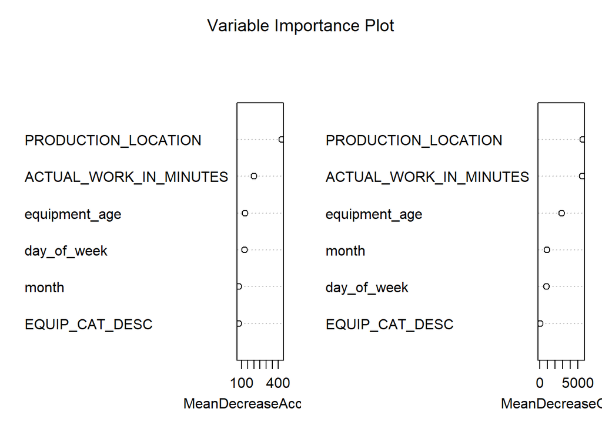

```r
# Plot variable importance
varImpPlot(rf_model, main="Variable Importance Plot")
```

The Random Forest model demonstrates strong predictive performance for unplanned maintenance events with 87% accuracy. The model excels at identifying both planned and unplanned maintenance cases, as shown by high precision (81.2%) and recall (74.8%). The variable importance analysis reveals that production location is the most crucial predictor, followed by actual work duration and equipment age. This suggests that maintenance patterns are heavily influenced by facility-specific factors. The model successfully identifies 5,465 unplanned maintenance events correctly while misclassifying only 1,262 planned maintenance cases, indicating reliable predictive power for maintenance planning.